# HDT1 Analisis Exploratorio

Juan Diego Avila

2023-01-27

## 4.3 ¿Cuál es la película que más votos tuvo?

```r
movies[movies$voteCount == max(movies$voteCount, na.rm = T),]$title
```

```
## [1] "Inception"
```

Inception es la película con más votos, con una cantidad de 30788 votos.

## 4.4 ¿Cuál es la peor película de acuerdo a los votos de todos los usuarios?

```r
movies[movies$voteCount == min(movies$voteCount, na.rm = T),]$title
```

```
##  [1] "La Mera Reyna del Sur"
##  [2] "Star Driver the Movie"
##  [3] "The Next Mega Tsunami"
##  [4] "Three Preludes for Solo Piano By Adam Sherkin"
##  [5] "Mom's Friend 2"
##  [6] "El silencio"
##  [7] "극장판 레이디버그: 미라클 스톤의 비밀"
##  [8] "Thor: Hammer Time"
##  [9] "Sing Along"
## [10] "Tar Pits Film"
## [11] "Catastr\xf3pico"
## [12] "Captain America: Civil War Reenactors"
## [13] "Los cazafantasmas de Petatiux"
## [14] "Sex School: Dorms of Desire"
## [15] "One Crazy Summer: A Look Back at Gravity Falls"
```

[output cut: 39 more lines]

```r
movies[movies$voteCount == min(movies$voteCount, na.rm = T),]$title[1]
```

```
## [1] "La Mera Reyna del Sur"
```

La Mera Reyna del Sur es la película con menos votos, con una cantidad de 1 voto/votos. Aunque muchas peliculas tienen esta cantidad de votos, se filtró el primer resultado.

## 4.5 ¿Cuántas películas se hicieron en cada año? ¿En qué año se hicieron más películas? Haga un gráfico de barras

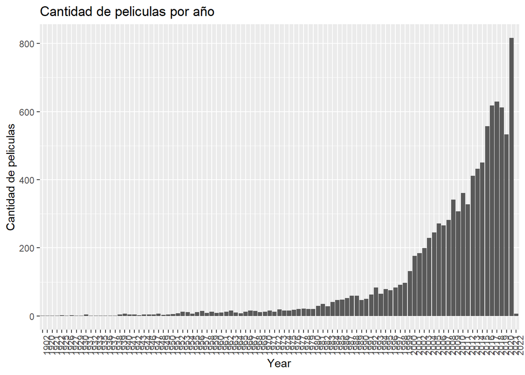

```r
fecha <- as.Date(movies$releaseDate)
year <- as.factor(format(fecha, "%Y"))
movies$year <- year
peliculas_por_ano <- group_by(movies, year)
resultado <- summarize(peliculas_por_ano, n=n())

ggplot(resultado ,
       aes(x = year, y = n) ) +
       geom_col() +
       xlab("Year") +
       ylab("Cantidad de peliculas") +
       ggtitle("Cantidad de peliculas por año")+
       theme(axis.text.x = element_text(angle = 90, hjust = 1))
```

Se hicieron más películas en el año 2021 teniendo una cantidad de 816.

[figure not shown]

```r
movies$releaseDate <- as.Date(movies$releaseDate, "%Y/%m/%d")
movies <- movies[order(movies$releaseDate),]
ultimas_veinte <- movies[1:20,]

ultimas_veinte$generos_separados <- strsplit(ultimas_veinte$genres, "\\|")
ultimas_veinte$genero_principal <- sapply(ultimas_veinte$generos_separados, `[`, 1)

ggplot(ultimas_veinte, aes(title, genero_principal)) +
  geom_bar(stat="identity") +
  xlab("Genero Principal") +
  ylab("Generos") +
  ggtitle("Genero principal de las 20 peliculas mas recientes") +
  theme(axis.text.x = element_text(angle = 90, hjust = 1))
```

```r
conteo_genero_principal <- table(ultimas_veinte$genero_principal)
genero_principal_total <- names(which.max(conteo_genero_principal))
```

```r
movies$generos_separados <- strsplit(movies$genres, "\\|")
movies$genero_principal <- sapply(ultimas_veinte$generos_separados, `[`, 1)
generos <- group_by(movies, genero_principal)
sumas_por_genero <- summarise(generos, revenue_sum = sum(revenue))
genero_con_mas_revenue <- head(sumas_por_genero, n = 1)
```

## 4.8 ¿La cantidad de actores influye en los ingresos de las películas? ¿Se han hecho películas con más actores en los últimos años?

```r
cor(movies$actorsAmount, movies$revenue)
```

```
## [1] -0.01955488
```

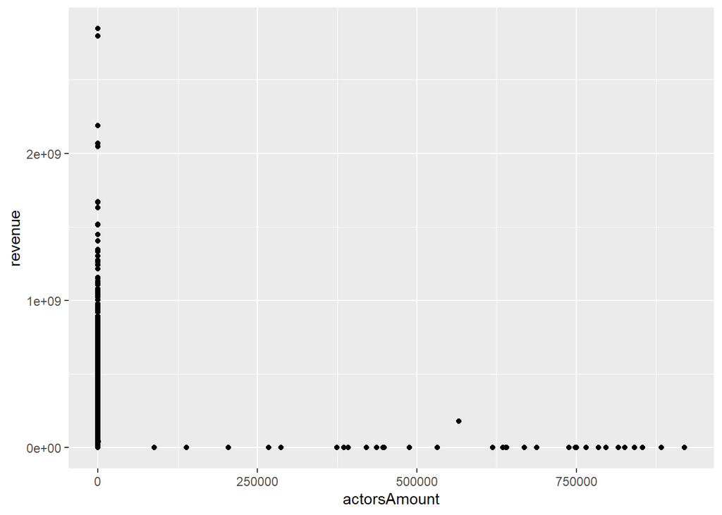

```r
movies$year <- year

ggplot(movies, aes(x=actorsAmount, y=revenue)) +
  geom_point()
```

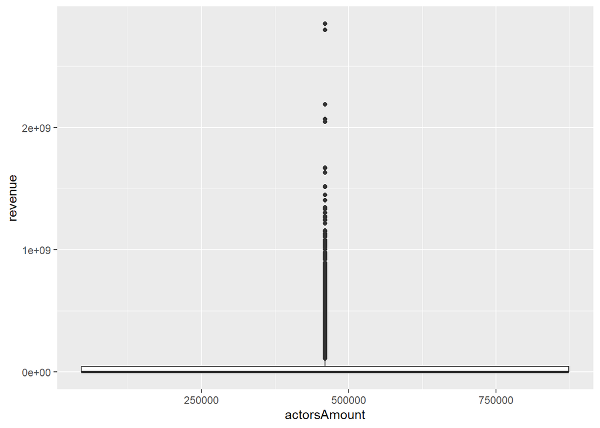

```r
ggplot(movies, aes(x=actorsAmount, y=revenue)) +
  geom_boxplot()
```

```r
summary(movies$actorsAmount)
```

```
##    Min. 1st Qu.  Median    Mean 3rd Qu.    Max.
##       0      13      21    2148      36  919590
```

```r
quantile(movies$actorsAmount, seq(0,1,0.01))
```

```
##        0%        1%        2%        3%        4%        5%        6%        7%
##      0.00      0.00      1.00      2.00      3.00      4.00      5.00      5.00
##        8%        9%       10%       11%       12%       13%       14%       15%
##      6.00      6.00      7.00      7.00      8.00      8.00      9.00      9.00
##       16%       17%       18%       19%       20%       21%       22%       23%
##     10.00     10.00     10.00     11.00     11.00     11.00     12.00     12.00
##       24%       25%       26%       27%       28%       29%       30%       31%
##     12.00     13.00     13.00     13.00     14.00     14.00     14.00     15.00
##       32%       33%       34%       35%       36%       37%       38%       39%
##     15.00     15.00     16.00     16.00     16.00     16.00     17.00     17.00
##       40%       41%       42%       43%       44%       45%       46%       47%
##     17.00     18.00     18.00     18.00     19.00     19.00     20.00     20.00
##       48%       49%       50%       51%       52%       53%       54%       55%
##     20.00     21.00     21.00     21.00     22.00     22.00     23.00     23.00
##       56%       57%       58%       59%       60%       61%       62%       63%
##     24.00     24.00     25.00     25.00     26.00     26.00     27.00     28.00
##       64%       65%       66%       67%       68%       69%       70%       71%
##     28.00     29.00     29.00     30.00     31.00     31.00     32.00     33.00
##       72%       73%       74%       75%       76%       77%       78%       79%
##     33.00     34.00     35.00     36.00     37.00     38.00     39.00     40.00
##       80%       81%       82%       83%       84%       85%       86%       87%
##     41.00     42.00     43.00     45.00     46.00     47.00     49.00     50.00
##       88%       89%       90%       91%       92%       93%       94%       95%
##     52.00     54.00     56.00     58.00     60.00     63.00     67.00     71.05
##       96%       97%       98%       99%      100%
##     77.00     84.00     96.00    123.00 919590.00
```

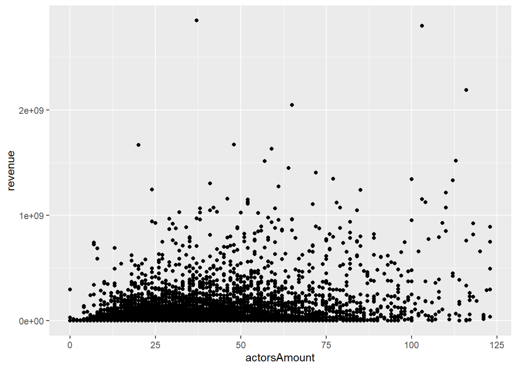

```r
menores <- movies[movies$actorsAmount <=  123, ]

ggplot(menores, aes(x=actorsAmount, y=revenue)) +
  geom_point()
```

Como se puede observar en la gráfica y con el valor de la correlación de -0.0195549, la cantidad de actores no influye en los ingresos. Encontrando los valores atípicos analizando los quantiles, separados con 0.01, se filtraron los valores menores a los valores atípicos y finalmente se confirmó que no tienen relación.

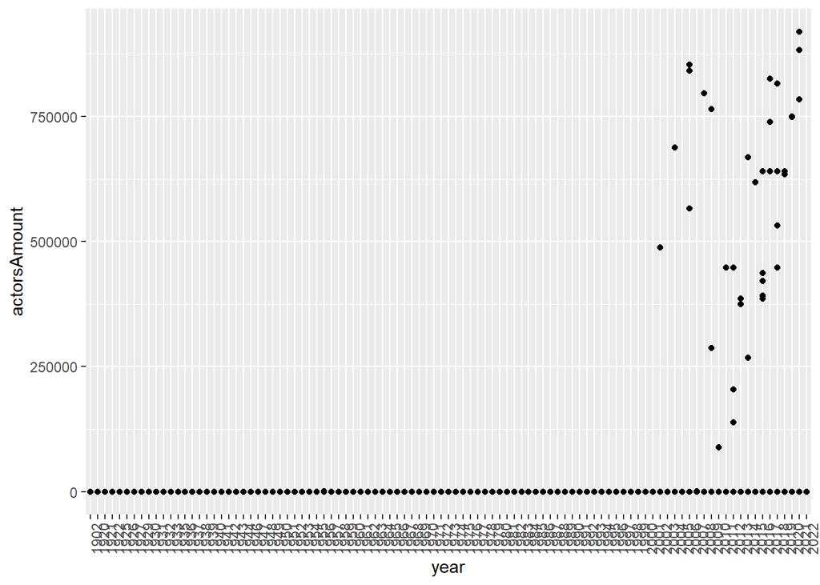

```r
ggplot(movies, aes(x=year, y=actorsAmount)) +
  geom_point() +
  theme(axis.text.x = element_text(angle = 90, hjust = 1))
```

## Pregunta extra: ¿La popularidad de los actores en la película afecta sus ingresos?

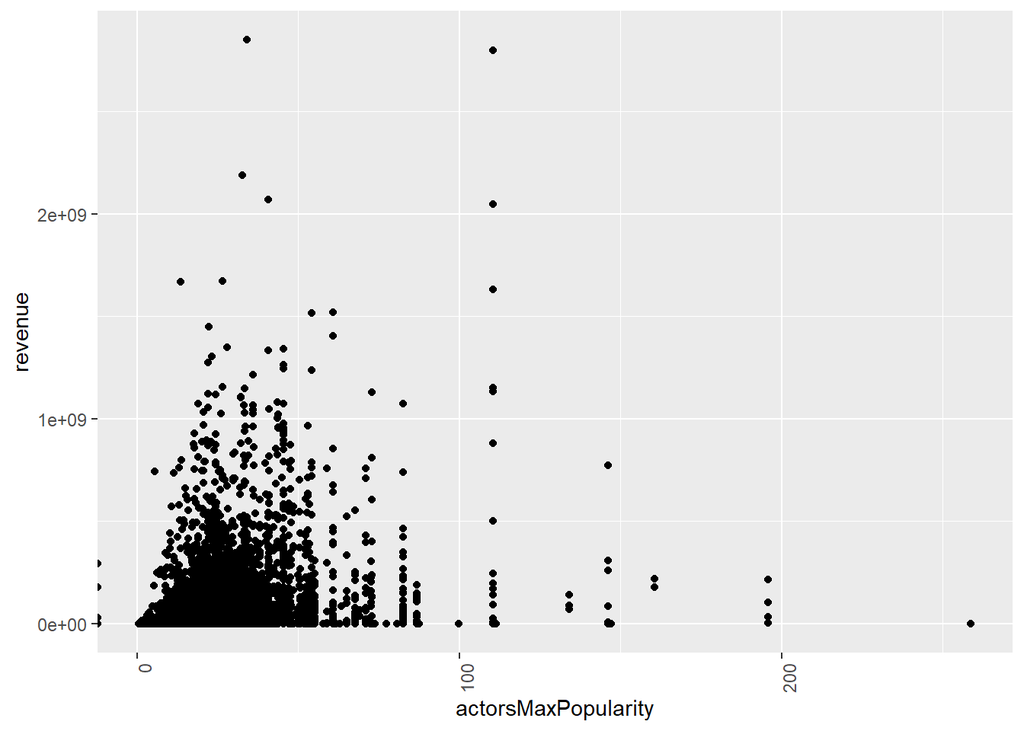

```r
movies$actorsMaxPopularity <- lapply(strsplit(movies$actorsPopularity, "\\|"), function(x) max(as.double(x)))

movies$actorsMaxPopularity <- as.numeric(movies$actorsMaxPopularity)
movies$revenue <- as.numeric(movies$revenue)
movies$actorsMaxPopularity<- movies$actorsMaxPopularity[1:nrow(movies)]

ggplot(movies, aes(actorsMaxPopularity, revenue)) +
 geom_point() +
 theme(axis.text.x = element_text(angle = 90, hjust = 1))
```

```r
cor(movies$revenue, movies$actorsMaxPopularity,method = "spearman", use="complete.obs")
```

```
## [1] 0.4299725
```

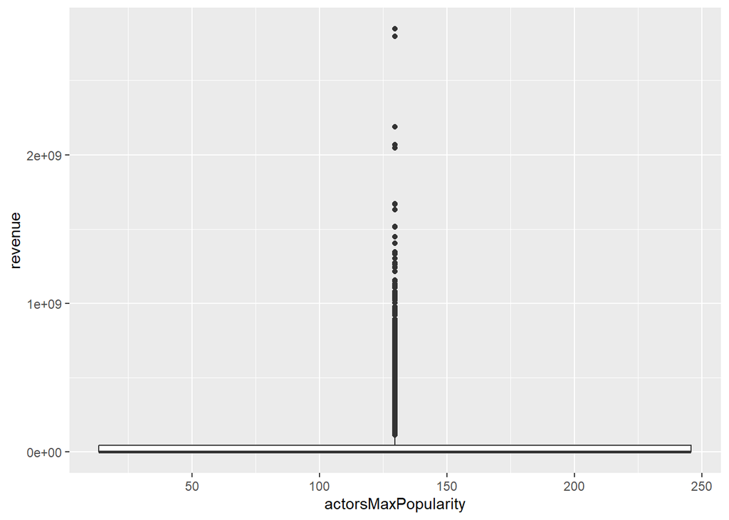

```r
ggplot(movies, aes(x=actorsMaxPopularity, y=revenue)) +
  geom_boxplot()
```

```r
quantile(movies$actorsMaxPopularity, seq(0,1,0.01), na.rm = T)
```

```
##        0%        1%        2%        3%        4%        5%        6%        7%
##      -Inf   0.60000   1.39112   2.13400   3.54244   4.54405   5.38046   6.16800
##        8%        9%       10%       11%       12%       13%       14%       15%
##   6.90240   7.56936   8.06000   8.62900   9.08104   9.55128   9.86892  10.29260
##       16%       17%       18%       19%       20%       21%       22%       23%
##  10.71164  11.12484  11.34872  11.62600  11.98160  12.40246  12.69300  12.91598
##       24%       25%       26%       27%       28%       29%       30%       31%
##  13.19100  13.50300  13.77200  14.04310  14.31600  14.65100  14.94090  15.22612
##       32%       33%       34%       35%       36%       37%       38%       39%
##  15.51248  15.78695  16.03968  16.24450  16.45500  16.69296  16.91764  17.19100
##       40%       41%       42%       43%       44%       45%       46%       47%
##  17.41540  17.65266  17.81600  18.18500  18.38400  18.60900  18.75400  19.06200
##       48%       49%       50%       51%       52%       53%       54%       55%
##  19.30900  19.58800  19.86500  20.27013  20.52000  20.75500  21.10014  21.39300
##       56%       57%       58%       59%       60%       61%       62%       63%
##  21.63800  21.96800  22.12300  22.27700  22.74300  22.96500  23.16700  23.44000
##       64%       65%       66%       67%       68%       69%       70%       71%
##  23.71200  24.12900  24.36600  24.54200  24.67000  25.05000  25.23900  25.61500
##       72%       73%       74%       75%       76%       77%       78%       79%
##  25.91000  26.07489  26.47000  27.08200  27.79704  27.99500  28.43200  29.38311
##       80%       81%       82%       83%       84%       85%       86%       87%
##  30.09000  31.04400  31.78300  32.15700  33.18800  33.39400  33.85200  34.60400
##       88%       89%       90%       91%       92%       93%       94%       95%
##  36.00900  36.69000  38.04200  40.34000  41.07500  43.88600  45.40100  47.61900
##       96%       97%       98%       99%      100%
##  52.26600  54.29900  65.21100  82.57000 258.80200
```

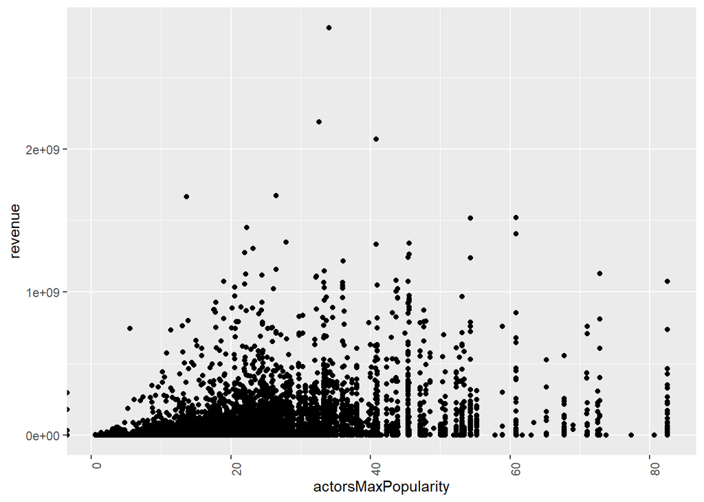

```r
menos <- movies[movies$actorsMaxPopularity <= 82.57,]

ggplot(menos, aes(actorsMaxPopularity, revenue)) +
 geom_point() +
 theme(axis.text.x = element_text(angle = 90, hjust = 1))
```

```r
colnames(movies)
```

```
##  [1] "id"                        "budget"
##  [3] "genres"                    "homePage"
##  [5] "productionCompany"         "productionCompanyCountry"
##  [7] "productionCountry"         "revenue"
##  [9] "runtime"                   "video"
## [11] "director"                  "actors"
## [13] "actorsPopularity"          "actorsCharacter"
## [15] "originalTitle"             "title"
## [17] "originalLanguage"          "popularity"
## [19] "releaseDate"               "voteAvg"
## [21] "voteCount"                 "genresAmount"
## [23] "productionCoAmount"        "productionCountriesAmount"
## [25] "actorsAmount"              "castWomenAmount"
## [27] "castMenAmount"             "year"
## [29] "generos_separados"         "genero_principal"
## [31] "actorsMaxPopularity"
```

[figure not shown]

```r
Matriz_correlacion <- cor(menos[,c("actorsMaxPopularity","revenue","budget","voteAvg","voteCount","popularity","genresAmount","actorsAmount")])

corrplot(Matriz_correlacion)
```

## Pregunta extra: ¿El lenguaje en el que se produjo la película tiene relación con los votos recibidos por pelicula?

```r
ingles <- movies[movies$originalLanguage == "en",]
nrow(ingles)
```

```
## [1] 7772
```

```r
otros <- movies[movies$originalLanguage != "en",]
nrow(otros)
```

```
## [1] 2228
```

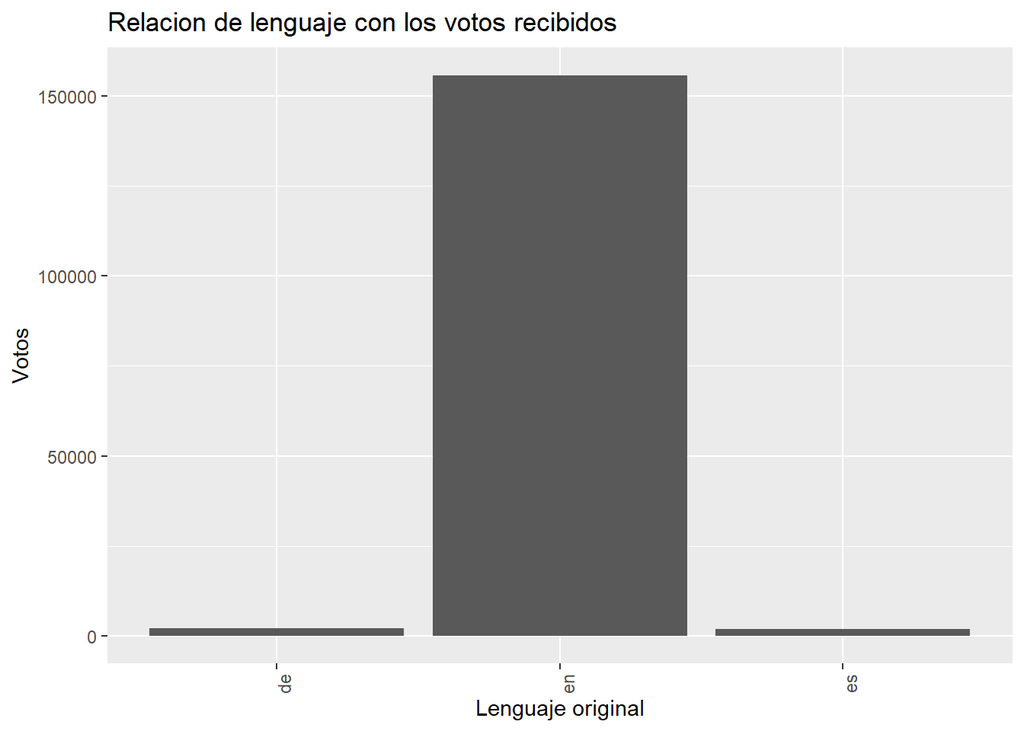

```r
ggplot(ultimas_veinte, aes(originalLanguage, voteCount)) +
  geom_bar(stat="identity") +
  xlab("Lenguaje original") +
  ylab("Votos") +
  ggtitle("Relacion de lenguaje con los votos recibidos") +
  theme(axis.text.x = element_text(angle = 90, hjust = 1))
```